# Beer Consumption in Sao Paulo

DESCRIPTION OF THE PROJECT

What is the topic?

Consumption of a beer in Sao Paulo, Brazil.

Where did you get it from?

https://www.kaggle.com/dongeorge/beer-consumption-sao-paulo

What kind of variables you have (numerical/categorical etc)? Describe the variables (the meaning of those).

/ *The original dataset was slightly changed (Spanish names were translated to English, two new columns, namely “Day_Of_The_Week” and “Month”, were added)* /

Numerical variables:

Date Average_Temperature_Celsius, Minimum Temperature_Celsius, Maximum Temperature_Celsius, Precipitation_mm, Beer_Consumption_ml

Categorical variables: Day_of_The_Week

Categorical variables (in numeric format): End_of_The_Week, Month

This dataset contains 365 rows of data (941 rows originally, however, rows with missing values were omitted).

Description of the variables

The “Date” variable has all 365 days of the year 2015

“Average_Temperature_Celsius” - Mean temperature for every day of the year 2015 in Sao Paulo “Minimum Temperature_Celsius” - self explanatory “Maximum Temperature_Celsius” - self explanatory

“Precipitation_mm” - the amount of precipitation in mm for every day of the year 2015 in Sao Paulo

“Day_of_The_Week” - name of the day of the week (by some reason in Russian, I assume it has something to do with the RStudio settings)

“Month” - months in numeric format (1 - January, 2 - February, etc.)

Loading dataset

```r
library(readr)

Consumo_cerveja <- read_csv("C:/Users/PC/Desktop/Consumo_cerveja.csv",
    col_types = cols(Data = col_date(format = "%Y-%m-%d")),
    locale = locale(grouping_mark = "."))

View(Consumo_cerveja)
```

Omitting NA values (all odd rows >365), renaming dataset, translating variables to English

```r
Beer_consumption <- na.omit(Consumo_cerveja)

rm(Consumo_cerveja)

names(Beer_consumption)[names(Beer_consumption) == "Data"] <- "Date"

names(Beer_consumption)[names(Beer_consumption) == "Temperatura Media (C)"] <- "Average_Temperature_Celsius"

names(Beer_consumption)[names(Beer_consumption) == "Temperatura Minima (C)"] <- "Minimum_Temperature_Celsius"

names(Beer_consumption)[names(Beer_consumption) == "Temperatura Maxima (C)"] <- "Maximum_Temperature_Celsius"

names(Beer_consumption)[names(Beer_consumption) == "Precipitacao (mm)"] <- "Precipitation_mm"

names(Beer_consumption)[names(Beer_consumption) == "Final de Semana"] <- "End_of_The_Week"

names(Beer_consumption)[names(Beer_consumption) == "Consumo de cerveja (litros)"] <- "Beer_Consumption_ml"
```

Distribution graphs

```r
# libraries

library(ggplot2)
library(dplyr)
```

12 months to a variable

```r
twelve_months <-  scale_x_date(breaks = as.Date(c("2015-01-01","2015-02-01","2015-03-01","2015-04-01","2015-05-01","2015-06-01","2015-07-01","2015-08-01","2015-09-01","2015-10-01","2015-11-01","2015-12-01")), label = c("Jan", "Feb", "Mar", "Apr", "May", "Jun", "Jul", "Aug", "Sep", "Oct", "Nov", "Dec"))
```

Beer consumption distribution graph:

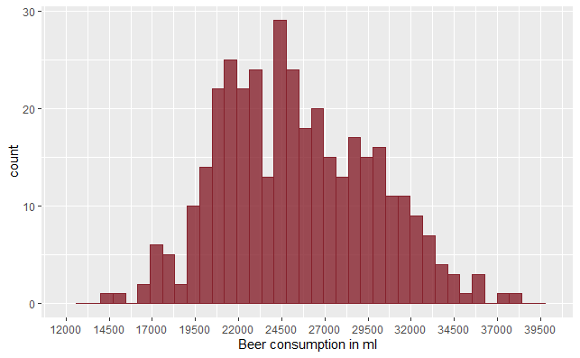

```r
ggplot(Beer_consumption, aes(x=Beer_Consumption_ml)) +
  geom_histogram(fill="#86212c", colour="#86212c", alpha=0.8, bins = 40) +
  scale_x_continuous(limits = c(12000, 40000), breaks = seq(12000,40000,2500)) +
  labs(x = "Beer consumption in ml")
```

All 365 days of beer consumption line plot:

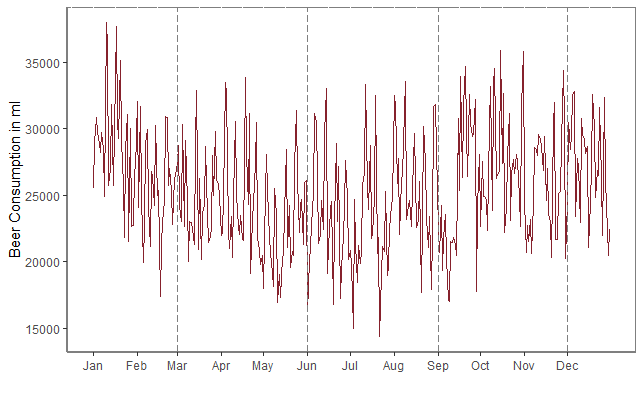

```r
ggplot(Beer_consumption, aes(Date, Beer_Consumption_ml)) + geom_line(colour = '#86212c') + geom_vline(xintercept = as.numeric(as.Date(c("2015-03-01", "2015-06-01", "2015-09-01", "2015-12-01"))), linetype = "longdash", size = 0.3, col = "gray50") + theme(panel.background = element_rect(fill = "white", colour = "grey50"), axis.line = element_line(colour = "grey50", size = 1, linetype = "solid")) + twelve_months + labs(x = "", y = "Beer Consumption in ml")
```

Average temperature distribution graph:

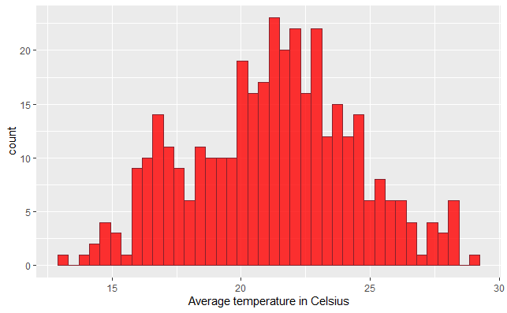

```r
ggplot(Beer_consumption, aes(x=Average_Temperature_Celsius)) +
  geom_histogram(fill="red", colour="#86212c", alpha=0.8, bins = 40) +
  labs(x = "Average temperature in Celsius")
```

Minimum temperature distribution graph:

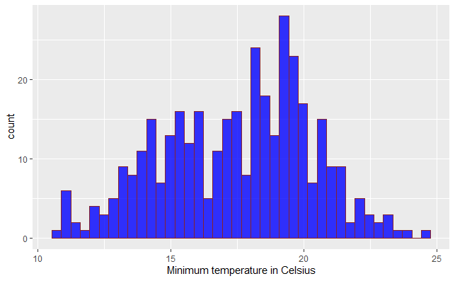

```r
ggplot(Beer_consumption, aes(x=Minimum_Temperature_Celsius)) +
  geom_histogram(fill="blue", colour="#86212c", alpha=0.8, bins = 40) +
  labs(x = "Minimum temperature in Celsius")
```

Maximum temperature distribution graph:

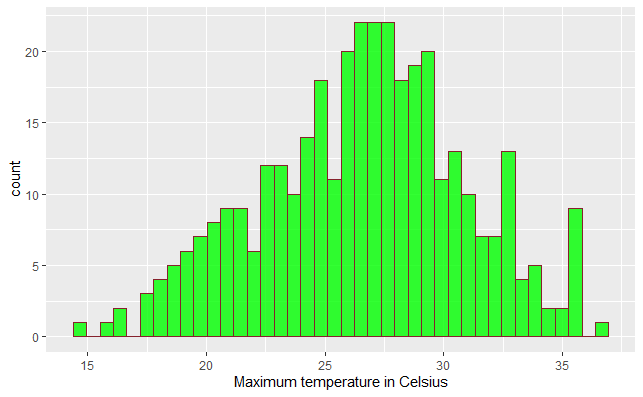

```r
ggplot(Beer_consumption, aes(x=Maximum_Temperature_Celsius)) +
  geom_histogram(fill="green", colour="#86212c", alpha=0.8, bins = 40) +
  labs(x = "Maximum temperature in Celsius")
```

Air temperature 1 year

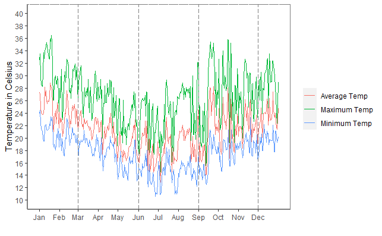

```r
ggplot(Beer_consumption, aes(Date)) +
  geom_line(aes(y = Average_Temperature_Celsius, colour = "Average Temp")) +
  geom_line(aes(y = Minimum_Temperature_Celsius, colour = "Minimum Temp")) +
  geom_line(aes(y = Maximum_Temperature_Celsius, colour = "Maximum Temp")) +
  labs(x = "", y = "Temperature in Celsius") +
  geom_vline(xintercept = as.numeric(as.Date(c("2015-03-01", "2015-06-01", "2015-09-01", "2015-12-01"))), linetype = "longdash", size = 0.3, col = "gray50") +
  theme(panel.background = element_rect(fill = "white", colour = "grey50"), axis.line = element_line(colour = "grey50", size = 1, linetype = "solid"), legend.title = element_blank()) +
  twelve_months + scale_y_continuous(breaks = seq(10,40,2), limits = c(10,40))
```

Quantitative overview of the data

Declaring a function to find the mode

```r
Mode <- function(x, na.rm = FALSE) {
  if(na.rm){
    x = x[!is.na(x)]
  }

  ux <- unique(x)
  return(ux[which.max(tabulate(match(x, ux)))])
}
```

CENTRAL TENDENCY OF ALL VARIABLES

Beer consumption in ml (mean, mean trimmed 25%, median, mode) code:

```r
beer_consumption_ml_mean <- mean(Beer_consumption[["Beer_Consumption_ml"]])

beer_consumption_ml_mean_trimmed_25 <- mean(Beer_consumption[["Beer_Consumption_ml"]], trim = 0.25)

beer_consumption_ml_median <- median(Beer_consumption[["Beer_Consumption_ml"]])

beer_consumption_ml_mode <- Mode(Beer_consumption[["Beer_Consumption_ml"]])
```

Precipitation in mm (mean, mean trimmed 25%, median, mode) code:

```r
precipitation_mm_mean <- mean(Beer_consumption[["Precipitation_mm"]])

precipitation_mm_mean_trimmed_25 <- mean(Beer_consumption[["Precipitation_mm"]], trim = 0.25)

precipitation_mm_median <- median(Beer_consumption[["Precipitation_mm"]])

precipitation_mm_mode <- Mode(Beer_consumption[["Precipitation_mm"]])
```

Average temperature in Celsius (mean, mean trimmed 25%, median, mode) code:

```r
average_temperature_celsius_mean <- mean(Beer_consumption[["Average_Temperature_Celsius"]])

average_temperature_celsius_mean_trimmed_25 <- mean(Beer_consumption[["Average_Temperature_Celsius"]], trim = 0.25)

average_temperature_celsius_median <- median(Beer_consumption[["Average_Temperature_Celsius"]])

average_temperature_celsius_mode <- Mode(Beer_consumption[["Average_Temperature_Celsius"]])
```

Maximum temperature in Celsius (mean, mean trimmed 25%, median, mode) code:

```r
max_temperature_celsius_mean <- mean(Beer_consumption[["Maximum_Temperature_Celsius"]])

max_temperature_celsius_mean_trimmed_25 <- mean(Beer_consumption[["Maximum_Temperature_Celsius"]], trim = 0.25)

max_temperature_celsius_median <- median(Beer_consumption[["Maximum_Temperature_Celsius"]])

max_temperature_celsius_mode <- Mode(Beer_consumption[["Maximum_Temperature_Celsius"]])
```

Minimum temperature in Celsius (mean, mean trimmed 25%, median, mode) code:

```r
min_temperature_celsius_mean <- mean(Beer_consumption[["Minimum_Temperature_Celsius"]])

min_temperature_celsius_mean_trimmed_25 <- mean(Beer_consumption[["Minimum_Temperature_Celsius"]], trim = 0.25)

min_temperature_celsius_median <- median(Beer_consumption[["Minimum_Temperature_Celsius"]])

min_temperature_celsius_mode <- Mode(Beer_consumption[["Minimum_Temperature_Celsius"]])
```

VARIABILITY MEASURES OF ALL VARIABLES

Beer consumption in ml (range, interquartile range, variance, standard deviation) code:

```r
beer_consumption_ml_range <- max(Beer_consumption[["Beer_Consumption_ml"]]) - min(Beer_consumption[["Beer_Consumption_ml"]])

beer_consumption_ml_interquartile_range <- IQR(Beer_consumption[["Beer_Consumption_ml"]])

beer_consumption_ml_variance <- var(Beer_consumption[["Beer_Consumption_ml"]])

beer_consumption_ml_standard_deviation <- sd(Beer_consumption[["Beer_Consumption_ml"]])
```

Precipitation in mm (range, interquartile range, variance, standard deviation) code:

```r
precipitation_mm_range <- max(Beer_consumption[["Precipitation_mm"]]) - min(Beer_consumption[["Precipitation_mm"]])

precipitation_mm_interquartile_range <- IQR(Beer_consumption[["Precipitation_mm"]])

precipitation_mm_variance <- var(Beer_consumption[["Precipitation_mm"]])

precipitation_mm_standard_deviation <- sd(Beer_consumption[["Precipitation_mm"]])
```

Average temperature in Celsius (range, interquartile range, variance, standard deviation) code:

```r
average_temperature_celsius_range <- max(Beer_consumption[["Average_Temperature_Celsius"]]) - min(Beer_consumption[["Average_Temperature_Celsius"]])

average_temperature_celsius_interquartile_range <- IQR(Beer_consumption[["Average_Temperature_Celsius"]])

average_temperature_celsius_variance <- var(Beer_consumption[["Average_Temperature_Celsius"]])

average_temperature_celsius_standard_deviation <- sd(Beer_consumption[["Average_Temperature_Celsius"]])
```

Minimum temperature in Celsius (range, interquartile range, variance, standard deviation) code:

```r
min_temperature_celsius_range <- max(Beer_consumption[["Minimum_Temperature_Celsius"]]) - min(Beer_consumption[["Minimum_Temperature_Celsius"]])

min_temperature_celsius_interquartile_range <- IQR(Beer_consumption[["Minimum_Temperature_Celsius"]])

min_temperature_celsius_variance <- var(Beer_consumption[["Minimum_Temperature_Celsius"]])

min_temperature_celsius_standard_deviation <- sd(Beer_consumption[["Minimum_Temperature_Celsius"]])
```

```r
max_temperature_celsius_range <- max(Beer_consumption[["Maximum_Temperature_Celsius"]]) - min(Beer_consumption[["Maximum_Temperature_Celsius"]])

max_temperature_celsius_interquartile_range <- IQR(Beer_consumption[["Maximum_Temperature_Celsius"]])

max_temperature_celsius_variance <- var(Beer_consumption[["Maximum_Temperature_Celsius"]])

max_temperature_celsius_standard_deviation <- sd(Beer_consumption[["Maximum_Temperature_Celsius"]])
```

Adding new variables (name of the weekday, month (numeric)):

```r
Beer_consumption$Day_Of_The_Week <- weekdays(as.Date(Beer_consumption$Date))

library(lubridate)

Beer_consumption$Month <- month(Beer_consumption$Date)
```

Beer consumption by one week:

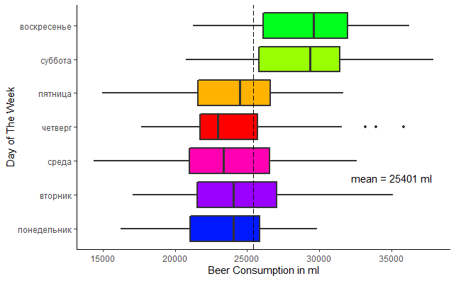

```r
Beer_consumption %>%
  group_by(Day_Of_The_Week) %>%
    ggplot(., aes(Day_Of_The_Week, Beer_Consumption_ml))+
    geom_boxplot(outlier.size = 1.7, outlier.shape = 20, lwd = 0.8, fatten = 1.5, fill = rainbow(n=7, start = 0.65, end = 0.35))+
    coord_flip() +
    geom_hline(yintercept = beer_consumption_ml_mean, linetype = "longdash", size = 0.4) +
    scale_x_discrete(limit = c("понедельник","вторник","среда","четверг","пятница","суббота","воскресенье")) +
  theme_classic() +
  annotate("text", label = "mean = 25401 ml", x = 2.5, y = 35000) +
  labs(x = "Day of The Week", y = "Beer Consumption in ml")
```

| Preparing dataset for correlation matrix |
| --- |

```r
tmp_data <- Beer_consumption %>% select(Average_Temperature_Celsius, Minimum_Temperature_Celsius, Maximum_Temperature_Celsius, Precipitation_mm, End_of_The_Week, Beer_Consumption_ml, Month)


### renaming to make it more readable in matrix


names(tmp_data)[names(tmp_data) == "Average_Temperature_Celsius"] <- "Avg_Temp_C"

names(tmp_data)[names(tmp_data) == "Minimum_Temperature_Celsius"] <- "Min_Temp_C"

names(tmp_data)[names(tmp_data) == "Maximum_Temperature_Celsius"] <- "Max_Temp_C"

names(tmp_data)[names(tmp_data) == "End_of_The_Week"] <- "Weekend"

names(tmp_data)[names(tmp_data) == "Beer_Consumption_ml"] <- "Beer_Consumption"

data <- cor(tmp_data)
```

Correlation matrix:

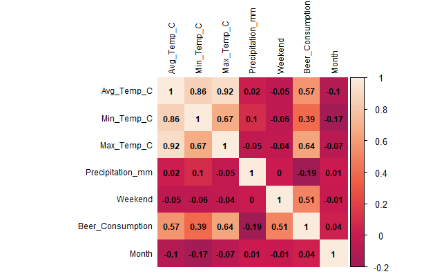

```r
corrplot(data, method="color", addCoef.col="black", tl.cex=0.75, tl.col="black", number.cex = 0.75, cl.ratio = 0.3, is.corr = FALSE, col = colorRampPalette(c("#000000", "#04051A", "#821E5A", "#CA1A50", "#F05C42", "#F6AA82", "#FAEBDD"))(200), cl.length = 7, cl.lim = c(-0.2, 1))
```

Observations: Beer consumption depends on air temperature (especially, on the max temperature), it is also important, whether it’s a weekend or not, there also a little correlation with the amount of precipitation.

| DEPENDENT VARIABLE vs INDEPENDENT VARIABLES |
| --- |

Dependent variable: “Beer_Consumption_ml”

Independent variables: all the others

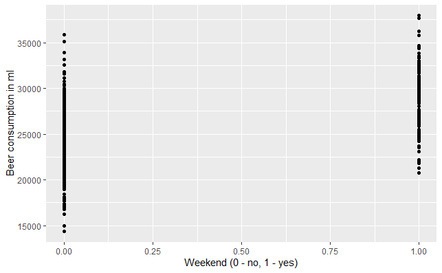

```r
ggplot(Beer_consumption, aes(x=End_of_The_Week, y=Beer_Consumption_ml)) +
  geom_point() +
  labs(x="Weekend (0 - no, 1 - yes)", y="Beer consumption in ml")
```

This plot shows that the minimum of consumed beer on weekends is higher than the minimum on working days, the maximum is also higher than maximum on working days

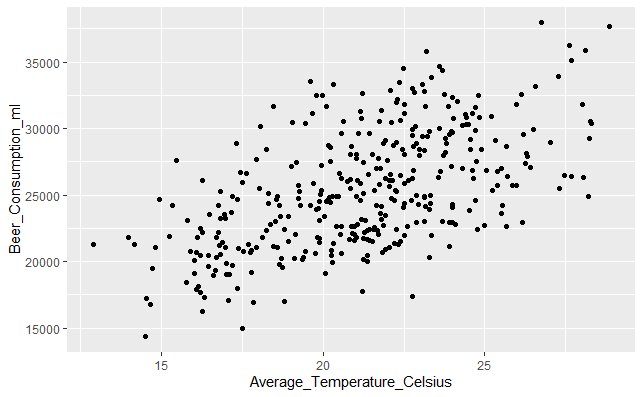

```r
ggplot(Beer_consumption, aes(x=Average_Temperature_Celsius, y=Beer_Consumption_ml)) +
  geom_point()
```

In this and next scatter plots we see that people tend to drink more as weather gets warmer.

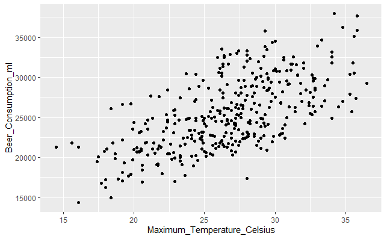

```r
ggplot(Beer_consumption, aes(x=Maximum_Temperature_Celsius, y=Beer_Consumption_ml)) + geom_point()
```

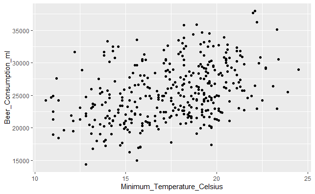

```r
ggplot(Beer_consumption, aes(x=Minimum_Temperature_Celsius, y=Beer_Consumption_ml)) + geom_point()
```

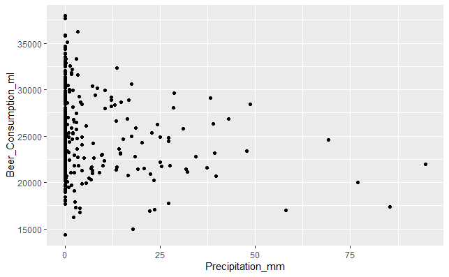

```r
ggplot(Beer_consumption, aes(x=Precipitation_mm, y=Beer_Consumption_ml)) + geom_point()
```

A little correlation between the amount of precipitation and amount of beer consumed. Mostly there were no precipitation, however on very rainy days people tend to drink less beer.

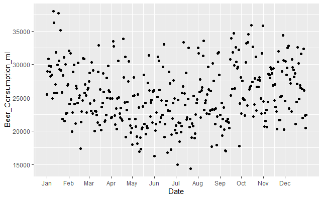

```r
ggplot(Beer_consumption, aes(Date, Beer_Consumption_ml)) + geom_point() + twelve_months
```

[output not shown]

Let’s take a look at the correlation between months and beer consumption

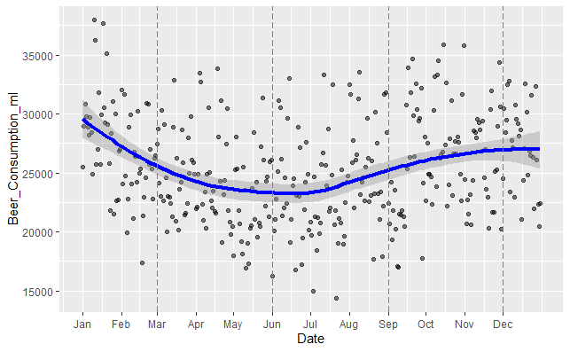

```r
ggplot(Beer_consumption, aes(Date, Beer_Consumption_ml)) + geom_point(alpha = 0.5) +           twelve_months +
  stat_smooth(aes(Date, Beer_Consumption_ml), method="loess", color = "blue", size=1.5, formula = y ~ x) +
  geom_vline(xintercept = as.numeric(as.Date(c("2015-03-01", "2015-06-01", "2015-09-01", "2015-12-01"))), linetype = "longdash", size = 0.3, col = "gray50")
```

The consumption of beer is noticeably higher in Mid-September - February, as we have seen previously, in these months in Sao Paulo are the warmest of all

[output not shown]

As we have seen in our correlation matrix, beer consumption has the higher correlation with the maximum temperature, let’s take a look at the plot:

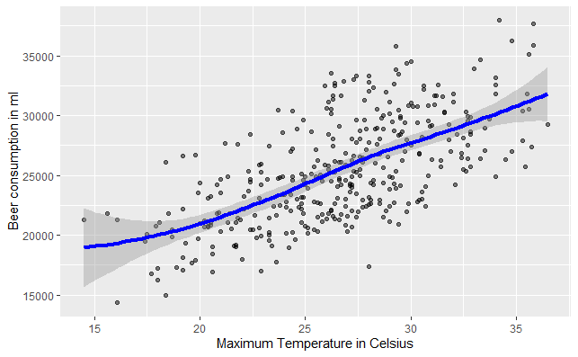

```r
ggplot(Beer_consumption, aes(x=Maximum_Temperature_Celsius, y=Beer_Consumption_ml)) +
  geom_point(alpha=0.5) +
  stat_smooth(aes(Maximum_Temperature_Celsius, Beer_Consumption_ml), method="loess", color = "blue", size=1.5, formula = y ~ x) +
  labs (x = "Maximum Temperature in Celsius", y = "Beer consumption in ml")
```

It is clear that people in Sao Paulo are drinking beer to refresh, and they drink more on the warm days

ONE MORE, NOW WITH THE PRECIPITATION

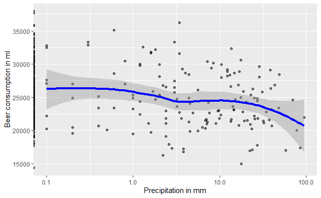

```r
ggplot(Beer_consumption, aes(x=Precipitation_mm, y=Beer_Consumption_ml)) +
  geom_point(alpha=0.5) +
  stat_smooth(aes(Precipitation_mm, Beer_Consumption_ml), method="loess", color = "blue", size=1.5, formula = y ~ x) +
  scale_x_continuous(trans = "log10") +
  labs(x = "Precipitation in mm", y = "Beer consumption in ml")
```

There is small correlation between the amount of precipitation and beer drinking. Consumption level falls when there is rainfall. However if there is a little rain, the difference is not significant.

Making a training and testing models. Proportion - 70/30

```r
smp_size <- floor(0.7 * nrow(Beer_consumption))

set.seed(123)
train_ind <- sample(seq_len(nrow(Beer_consumption)), size = smp_size)

training_set <- Beer_consumption[train_ind, ]
testing_set <- Beer_consumption[-train_ind, ]
```

Developing a model on training dataset, use it to predict the beer consumption on test data

```r
model <- lm(Beer_Consumption_ml ~ ., training_set)

p <- predict(model, testing_set)
```

```
prediction from a rank-deficient fit may be misleading
```

```r
actuals_preds <- data.frame(cbind(actuals=testing_set$Beer_Consumption_ml, predicteds=p))

correlation_accuracy <- cor(actuals_preds)
```

```r
show(correlation_accuracy)
```

```
             actuals predicteds
actuals    1.0000000  0.8488455
predicteds 0.8488455  1.0000000
```

~ 84.9%

```r
head(actuals_preds)
```

|  | actuals | predicteds |
| --- | --- | --- |
| 1 | 30814 | 30919.09 |
| 2 | 28218 | 25967.11 |
| 3 | 28397 | 24780.97 |
| 4 | 25743 | 30077.95 |
| 5 | 25724 | 27712.30 |
| 6 | 37690 | 34763.88 |

MAPE, RMSE, MAE, MinMaxAccuracy metrics

MAPE (lower the better):

```r
mape <- mean(abs((actuals_preds$predicteds - actuals_preds$actuals)) / actuals_preds$actuals)

show(mape)
```

```
[1] 0.07877571
```

~ 7.9%

RMSE (lower the better):

```r
rmse <- sqrt(mean((actuals_preds$predicteds - actuals_preds$actuals)^2))

show(rmse)
```

```
[1] 2272.87
```

MAE (lower the better):

```r
mae <- mean(abs(actuals_preds$predicteds - actuals_preds$actuals))

show(mae)
```

```
[1] 1932.509
```

MinMaxAccuracy (higher the better):

```r
min_max_accuracy <- mean(apply(actuals_preds, 1, min) / apply(actuals_preds, 1, max))

show(min_max_accuracy)
```

```
[1] 0.9260819
```

~ 92.6%

The prediction worked good, RMSE and other metrics have decent result (keep in mind we predict beer consumption measured in ml).

Conclusion

1. People in studied area drink more on warm days
2. Heavy rainfall make people to drink less, however little rain makes from little to no difference in beer consumption
3. People drink more on weekends